# Coursera Practical ML Project

Mostafa Hussien

2022-10-01

## Libraries

Lets load the required libraries

```r
load_libraries <- function(){
  library(caret); library(kernlab); library(ISLR); library(ggplot2); library(Hmisc); library(tidyverse)
  library(GGally); require(splines); library(AppliedPredictiveModeling); library(rattle)
  library(rpart); library(randomForest); library(gbm); library(klaR)
  library(quantmod); library(forecast); library(elasticnet); library(e1071)
}

load_libraries()
```

## Data Import

The data can be downloaded and obtained as follows

```r
#training data
download.file("https://d396qusza40orc.cloudfront.net/predmachlearn/pml-training.csv", "training.csv", method = "curl")
#test data
download.file("https://d396qusza40orc.cloudfront.net/predmachlearn/pml-testing.csv", "testing.csv", method = "curl")
pml.train <- read.csv('training.csv', na.strings = c('NA',''))
pml.test <- read.csv('testing.csv')
```

## Train Data Investigation

Lets investigate the train dataset and transform the ‘classe’ into factor variable

```r
#for safety take copy
pml.train.1 <- pml.train
pml.test.1 <- pml.test

#transform
pml.train.1$classe <- as.factor(pml.train.1$classe)

#check column names
pml.train.1 %>% names()
```

```
##   [1] "X"                        "user_name"
##   [3] "raw_timestamp_part_1"     "raw_timestamp_part_2"
##   [5] "cvtd_timestamp"           "new_window"
##   [7] "num_window"               "roll_belt"
##   [9] "pitch_belt"               "yaw_belt"
##  [11] "total_accel_belt"         "kurtosis_roll_belt"
##  [13] "kurtosis_picth_belt"      "kurtosis_yaw_belt"
##  [15] "skewness_roll_belt"       "skewness_roll_belt.1"
##  [17] "skewness_yaw_belt"        "max_roll_belt"
##  [19] "max_picth_belt"           "max_yaw_belt"
##  [21] "min_roll_belt"            "min_pitch_belt"
##  [23] "min_yaw_belt"             "amplitude_roll_belt"
##  [25] "amplitude_pitch_belt"     "amplitude_yaw_belt"
##  [27] "var_total_accel_belt"     "avg_roll_belt"
##  [29] "stddev_roll_belt"         "var_roll_belt"
```

[output cut: 65 more lines]

It looks like the first 7 columns are useless in predicting, lets remove them!

```r
#for safety take copy
pml.train.1 <- pml.train.1[,-c(1:7)]
```

What about NAs? Are there any? Lest find out!

```r
#for safety take copy
pml.train.1 %>% str()
```

```
## 'data.frame':    19622 obs. of  153 variables:
##  $ roll_belt               : num  1.41 1.41 1.42 1.48 1.48 1.45 1.42 1.42 1.43 1.45 ...
##  $ pitch_belt              : num  8.07 8.07 8.07 8.05 8.07 8.06 8.09 8.13 8.16 8.17 ...
##  $ yaw_belt                : num  -94.4 -94.4 -94.4 -94.4 -94.4 -94.4 -94.4 -94.4 -94.4 -94.4 ...
##  $ total_accel_belt        : int  3 3 3 3 3 3 3 3 3 3 ...
##  $ kurtosis_roll_belt      : chr  NA NA NA NA ...
##  $ kurtosis_picth_belt     : chr  NA NA NA NA ...
##  $ kurtosis_yaw_belt       : chr  NA NA NA NA ...
##  $ skewness_roll_belt      : chr  NA NA NA NA ...
##  $ skewness_roll_belt.1    : chr  NA NA NA NA ...
##  $ skewness_yaw_belt       : chr  NA NA NA NA ...
##  $ max_roll_belt           : num  NA NA NA NA NA NA NA NA NA NA ...
##  $ max_picth_belt          : int  NA NA NA NA NA NA NA NA NA NA ...
##  $ max_yaw_belt            : chr  NA NA NA NA ...
##  $ min_roll_belt           : num  NA NA NA NA NA NA NA NA NA NA ...
```

[output cut: 86 more lines]

Yes there are NAs indeed. Lets get rid of them

```r
#dimensions before removing NA columns
pml.train.1 %>% dim()
```

```
## [1] 19622   153
```

```r
#extract column names that has more than 90% NAs
tibble(
  colmn= names(
    sapply(pml.train.1, function(x) {mean(is.na(x))})
    ),
  sna= sapply(pml.train.1, function(x) {sum(is.na(x))}),
  mna= sapply(pml.train.1, function(x) {mean(is.na(x))})
) %>%
  arrange(desc(mna)) %>%
  filter(mna<0.9) %>%
  pluck('colmn') -> pml.non.na.colmn


#remove na columns
pml.train.1 <- pml.train.1[,pml.non.na.colmn]

#dimensions after
pml.train.1 %>% dim()
```

```
## [1] 19622    53
```

Wow!! There were 100 columns with more than 90% NAs!

## Data Splitting

So, for the train dataset; this is going to be split into training and testing datasets

While for the test dataset, this is going to be left for the final prediction step after all the modeling

```r
pml.train.split <- createDataPartition(y=pml.train.1$classe, p=0.75, list = F)

pml.train.2 <- pml.train.1[pml.train.split,]
pml.test.2 <- pml.train.1[-pml.train.split,]

#dimensions
pml.train.2 %>% dim()
```

```
## [1] 14718    53
```

```r
pml.test.2 %>% dim()
```

```
## [1] 4904   53
```

## Preparing Final Testing Data Accordingly

What was done on the training data should be done on the final test data

```r
pml.test.final  <- pml.test[,colnames(pml.test) %in% pml.non.na.colmn]
pml.test.final %>% dim()
```

```
## [1] 20 52
```

## Modeling Training Data

What is the kind of response?

```r
pml.train.2$classe %>% unique()
```

```
## [1] A B C D E
## Levels: A B C D E
```

Therefore; multinomial

Hence, the following algorithms will be used

- Tree
- Random Forest
- LDA
- Naive Bayes
- Bagging
- SVM

```r
#tree
pml.fit.tree <- train(classe~., method='rpart', data= pml.train.2)

#rf
pml.fit.rf <- randomForest(classe~., data= pml.train.2)

#lda
pml.fit.lda <- train(classe~., method='lda', data= pml.train.2)

#nb
pml.fit.nb <- naiveBayes(classe~., data= pml.train.2)

#bagging
pml.fit.bag <- bag(pml.train.2[,-53],
                   pml.train.2[,53],
                   B=10,
                   bagControl = bagControl(fit= ctreeBag$fit,
                                           predict= ctreeBag$pred,
                                           aggregate = ctreeBag$aggregate)
                   )
#svm
pml.fit.svm <- svm(classe~., data= pml.train.2)
```

## Training Prediction

Lets predict on the training data to obtain training accuracy metrics

```r
#tree
pml.pred1.tree <- predict(pml.fit.tree, pml.test.2)

#rf
pml.pred1.rf <- predict(pml.fit.rf, pml.test.2)

#lda
pml.pred1.lda <- predict(pml.fit.lda, pml.test.2)

#nb
pml.pred1.nb <- predict(pml.fit.nb, pml.test.2)

#bagging
pml.pred1.bagging <- predict(pml.fit.bag, pml.test.2)

#svm
pml.pred1.svm <- predict(pml.fit.svm, pml.test.2)
```

## Training Accuracy

Lets arrange the training accuracy in a tibble arranged by value

```r
tr_acc <- tibble(
  Algo= (c('Tree', 'RF', 'LDA', 'NB', 'Bagging',
           #'Boosting', 'KMeans',
           'SVM')),
  Set= 'Train',
  Accuracy= c(
    confusionMatrix(pml.train.2$classe, predict(pml.fit.tree))$overall['Accuracy'],
    confusionMatrix(pml.train.2$classe, predict(pml.fit.rf))$overall['Accuracy'],
    confusionMatrix(pml.train.2$classe, predict(pml.fit.lda))$overall['Accuracy'],
    confusionMatrix(pml.train.2$classe, predict(pml.fit.nb, pml.train.2))$overall['Accuracy'],
    confusionMatrix(pml.train.2$classe, predict(pml.fit.bag,pml.train.2))$overall['Accuracy'],
    confusionMatrix(pml.train.2$classe, predict(pml.fit.svm))$overall['Accuracy']
  )
)

tr_acc %>% arrange(desc(Accuracy))
```

```
## # A tibble: 6 × 3
##   Algo    Set   Accuracy
##   <chr>   <chr>    <dbl>
## 1 RF      Train    0.995
## 2 Bagging Train    0.984
## 3 SVM     Train    0.959
## 4 LDA     Train    0.705
## 5 NB      Train    0.559
## 6 Tree    Train    0.497
```

RF ROCKS !!!

## Testing Accuracy

Lets check the testing accuracy

```r
tst_acc <- tibble(
  Algo= (c('Tree', 'RF', 'LDA', 'NB', 'Bagging', 'SVM')),
  Set= 'Test',
  Accuracy= c(
    confusionMatrix(pml.test.2$classe, predict(pml.fit.tree, pml.test.2))$overall['Accuracy'],
    confusionMatrix(pml.test.2$classe, predict(pml.fit.rf, pml.test.2))$overall['Accuracy'],
    confusionMatrix(pml.test.2$classe, predict(pml.fit.lda, pml.test.2))$overall['Accuracy'],
    confusionMatrix(pml.test.2$classe, predict(pml.fit.nb, pml.test.2))$overall['Accuracy'],
    confusionMatrix(pml.test.2$classe, predict(pml.fit.bag,pml.test.2))$overall['Accuracy'],
    confusionMatrix(pml.test.2$classe, predict(pml.fit.svm, pml.test.2))$overall['Accuracy']
  )
)

tst_acc %>% arrange(desc(Accuracy))
```

```
## # A tibble: 6 × 3
##   Algo    Set   Accuracy
##   <chr>   <chr>    <dbl>
## 1 RF      Test     0.995
## 2 Bagging Test     0.960
## 3 SVM     Test     0.951
## 4 LDA     Test     0.699
## 5 NB      Test     0.558
## 6 Tree    Test     0.493
```

RF still ROCKS !!

## Visual Summary of Accuracy

How do the models perform? Lets see a visual

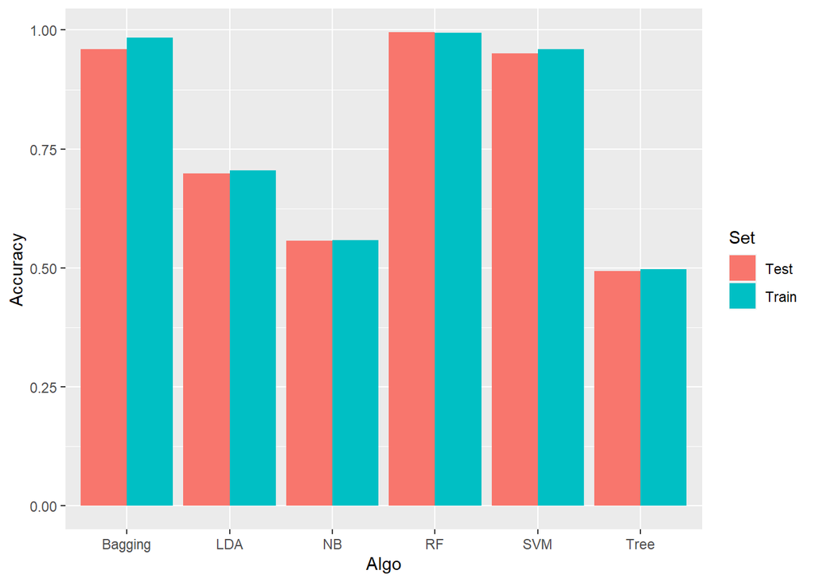

```r
acc_tbl <- bind_rows(
  tr_acc,
  tst_acc
)

acc_tbl %>%
  ggplot(aes(x=Algo, y=Accuracy, fill= Set)) +
  geom_col(position='dodge')
```

## Predicting

Indeed we will predict now using Random Forest

```r
predict(pml.fit.rf, pml.test.1)
```

```
##  1  2  3  4  5  6  7  8  9 10 11 12 13 14 15 16 17 18 19 20
##  B  A  B  A  A  E  D  B  A  A  B  C  B  A  E  E  A  B  B  B
## Levels: A B C D E
```